# Variable selection in regression with compositional covariates

Group 32 PB18000072 李云帆 PB18000106 周子乔

## Background

- **Compositional data**
  - Compositional data, which consist of the proportions or percentages of a composition, appear frequently in a wide range of applications; examples include geochemical compositions of rocks in geology, household patterns of expenditure in economics, species compositions of biological communities in ecology, and topic compositions of documents in machine learning. The fact that the components of a composition must sum to unity renders many standard multivariate statistical methods inappropriate or inapplicable.
- **Questions and the Log-contrast models**
  - Log-contrast models were originally introduced by Aitchison & Bacon-Shone (1984) for modelling experiments with mixtures, and have proved to be useful for a wide variety of regression problems with a composition playing the role of covariate.
  - Suppose that we observe an n-vector y of responses and an $n × p$ matrix $X = (x_{ij})$ of covariates, with each row of $X$ lying in the $(p − 1)$-dimensional positive simplex $\,\,S^{p-1}=\{{(x_{1},\cdots,x_{p}):x_{j}>0 \,\,(j=1,2,\cdots,p),\sum_{j=1}^p x_{j}=1}\}\,\,$. Because of the unit-sum constraint, the $p$ components of a composition cannot vary freely; therefore traditional methodology often requires the omission of certain components to ensure identifiability, and so encounters intrinsic difficulties in providing sensible interpretations for the regression parameters. To resolve these difficulties, Aitchison & Bacon-Shone (1984) proposed applying the log-ratio transformation (Aitchison, 1982) to compositional covariates, resulting in the **linear log-contrast model**.
    $$y=Z^{p}\beta_{\backslash p}^{*}+\varepsilon\,\,\,\,\text{(model 1)}\,\,\,\,\,(1)$$
  - where$\,\,Z^{p}=\{\text{log}(x_{ij}/x_{ip})\}\,\,$is the $\,n × (p − 1)\,$ log-ratio matrix whose $p$th component is the reference component, $\,\,\beta_{\backslash p}^{*}=(\beta_{1}^{*},\cdots,\beta_{p-1}^{*})^{T}\,\,$ is the corresponding $(p − 1)$-vector of regression coefficients, and $\,\varepsilon\,$is an n-vector of independent noise distributed as $N(0,\sigma^{2})$. By introducing a new coefficient $\,\,\beta_{p}^{*}=-\sum_{j=1}^{p-1}\beta_{j}^{*}\,\,$, model (1) can be more conveniently expressed in the symmetric form
    $$y=Z\beta^{*}+\varepsilon,\,\,\sum_{j=1}^{p}\beta_{j}^{*}=0\,\,\,\,\text{(model 2)}\,\,\,\,\,(2)$$
- **Applying the $L_{1}$ regularization**
  - We do not include an intercept in the model, since it can be eliminated by centring the response and predictor variables. We are concerned with the high dimensional sparse setting, where the dimensionality $\text{p}$ is comparable to or much larger than the sample size $\text{n}$, while only a few of the regression coefficients are nonzero.
  - Applying the $L_{1}$ regularization approach to model (2), we consider the constrained convex optimization problem
    $$\hat{\beta}=\text{argmin}_{\beta}(\frac{1}{2n}||y-Z\beta||^{2}+\lambda||\beta||_{1})$$
    $$\text{subject to} \,\,\sum_{j=1}^{p}\beta_j=0\,\,\,\,\,\,(3)$$
  - where $\beta=(\beta_{1},\beta_{2},\cdots,\beta_{p})^{T}$, $λ > 0$ is a regularization parameter, and $||\cdot||_{2}$ and $||\cdot||_{1}$ denote the $L_{2}$ norms and $L_{1}$norms, respectively.

## Optimization algorithm

- To derive the algorithm, we first form the augmented Lagrangian for the problem $(3)$,
  $$L_{\mu}(\beta,\gamma)=\frac{1}{2n}||y-Z\beta||_{2}^{2}+\lambda||\beta||_{1}+\gamma\sum_{j=1}^p\beta_{j}+\frac{\mu}{2}(\sum_{j=1}^{p}\beta_{j})^2$$
- where $\gamma$ is the Lagrange multiplier and $\mu > 0$ is a penalty parameter. The method of multipliers for the problem consists of the iterations
  $$\beta^{k+1}\longleftarrow\text{argmin}_{\beta}L_{\mu}(\beta,\gamma^{k})$$
  $$\gamma^{k+1}\longleftarrow\gamma^{k}+\mu\sum_{j=1}^{p}\beta_{j}^{k+1}$$
- Define the scaled Lagrange multiplier $\alpha=\gamma/\mu$ . Then the above iterations can be more conveniently expressed as
  $$\beta^{k+1}\longleftarrow\text{argmin}_{\beta}\{\frac{1}{2n}||y-Z\beta||_{2}^{2}+\lambda||\beta||_1+\frac{\mu}{2}(\sum_{j=1}^{p}\beta_{j}+\alpha^{k})^2\}\,\,\,\,\,\,(4)$$
  $$\alpha^{k+1}\longleftarrow\alpha^{k}+\sum_{j=1}^{p}\beta_{j}^{k+1}\,\,\,\,\,\,(5)$$
- Now the $L_1$ terms in $(4)$ are separable and the subproblem can be solved by coordinate descent. With the other components held fixed, the $\text{j}$th component of $\beta$ is updated by
  $$\beta_{j}^{k+1}\longleftarrow\frac{1}{v_{j}+\mu}S_{\lambda}
  \left(
  \frac{1}{n}z_{j}^{T}(y-\sum_{i\neq j}\beta_{i}^{k+1}z_{i})-\mu(\sum_{i\neq j}\beta_{i}^{k+1}+\alpha^{k})
  \right)\,\,\,\,\,\,(6)$$
- where $v_j=||z_j||_2^2/n$ and $S_{\lambda}=sgn(t)(|t|-\lambda)_{+}$ is the soft thresholding operator. Combining $(4)–(6)$ yields the following coordinate descent method of multipliers for solving problem $(3)$.
- **Algorithm: Coordinate descent method of multipliers**
  - Step 1. Initialize $\beta_{0}$ with 0 or a warm start, $\alpha^0=0$, $\mu>0$ , and $k = 0$ .
  - Step 2. For $j=1,\cdots,p$, update $\beta_{j}^{k+1}$ by (6) until convergence.
  - step 3. Update $\alpha^{k+1}$ by (5).
  - Step 4. Update $k ← k + 1$ , and repeat Steps 2 and 3 until convergence. Output $\hat{\beta}=\beta^{k+1}$
- **Algorithm Flow Chart**

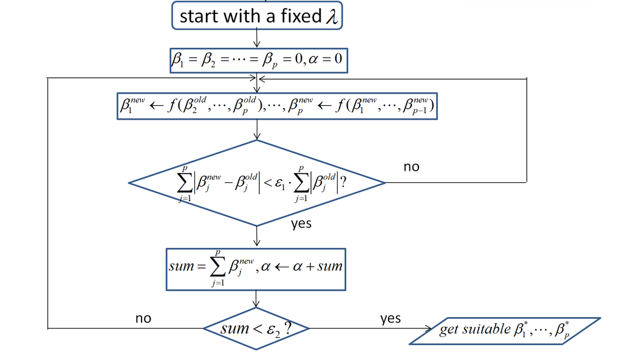

## Subroutine

```r
library(DT)
functiontable<-data.frame("函数名"=c("get_beta","get_lamda","get_group_beta","select_GIC"),input=c("y,x,lamda","y,x,the number of lamda","y,x","y,x, a state whether the beta is constrained "),output=c("the suitable beta","a group of lamda","a group of lamda and the corresponding beta","the optimal lamda and the corresponding beta"))
```

**函数功能汇总表**

```r
library(kableExtra)
kable(functiontable) %>%
kable_styling("striped", full_width = F)
```

| 函数名 | input | output |
| --- | --- | --- |
| get_beta | y,x,lamda | the suitable beta |
| get_lamda | y,x,the number of lamda | a group of lamda |
| get_group_beta | y,x | a group of lamda and the corresponding beta |
| select_GIC | y,x, a state whether the beta is constrained | the optimal lamda and the corresponding beta |

- **get_beta function**
  - $input:\\ n-vector\,\,\, y \,\,\,of\,\,\,\, responses\\ X=(x_{ij})\,\, of\,\, covariates\\ \lambda\,\,\,\,\, L1-term\,\,\, parameter$
  - $output:\\get\,\,\,suitable\,\,\,\beta_1^{*},\cdots,\beta_{p}^{*}$
  - $code$

```r
soft<-function(lam,t)#软阈值算子函数
{
  if(t<=-lam){
    return(t+lam)
  }else if(t>=lam){
    return(t-lam)
  }else{
    return (0)
  }
}
```

```r
get_beta<-function(y,x,fac,lam,mu=1,maxit=c(100,100),epis=c(1e-5,1e-5))
  {
  beta<-numeric(p)
  maxit_outer<-maxit[1]
  maxit_inner<-maxit[2]
  epis1<-epis[1]
  epis2<-epis[2]
  alp=sums=0
  for(i in 1:p){
    res[i]<-y[i]
  }#res对应y与求和项之差
  for(itouter in 1:maxit_outer){
    for(itinner in 1:maaxit_inner){
      difsum=fabsum=fabsum_old=0
      for(i in 1:p){
        old<-beta[i]
        t<-0
        for(k in 1:n){
          t=t+res[k]*x[[k,i]]
        }
        t=(t-mu*(alp+sum))*(1/(1+mu))+beta[i]
        beta[i]<-soft(lam,t)
        dif<-beta[i]-old
        sum=sum+fac[i]*dif
        for(k in 1:n){
          res[k]=res[k]-x[[k,i]]*dif
        }
        difsum<-difsum+abs(dif)
        fabsum<-fabsum+abs(beta[i])
      }
        fabsum_old<-fabsum
        if(difsum<epis1*fabsum_old) break #内层循环判断条件
        }
    if(abs(sums)<epis2) break #外层循环判断条件
  }
  return(beta)
}
```

- **get_lamda function**
  - $input:\\ n-vector\,\,\, y \,\,\,of\,\,\,\, responses\\ X=(x_{ij})\,\, of\,\, covariates\\ the\,\,\,number\,\,\,of\,\,\,\lambda$
  - $output:generate\,\,\, corresponding\,\,\, number\,\,\, of\,\,\,\lambda$
  - $code$

```r
get_lamda<-function(y,x,nlam){
  lam.max<-max(abs(crossprod(x,y)))
  lam<-lam.max*exp(seq(0,log(1/nlam),length=nlam))
  return(lam)
}
```

- **get_group_beta function**
  - $input:\\ n-vector\,\,\, y \,\,\,of\,\,\,\, responses\\ X=(x_{ij})\,\, of\,\, covariates$
  - $output:\\a\,\,group\,\,of\,\, \lambda\,\, and\,\, the\,\, corresponding\,\, \beta$
  - $sketch\,\,\, map$

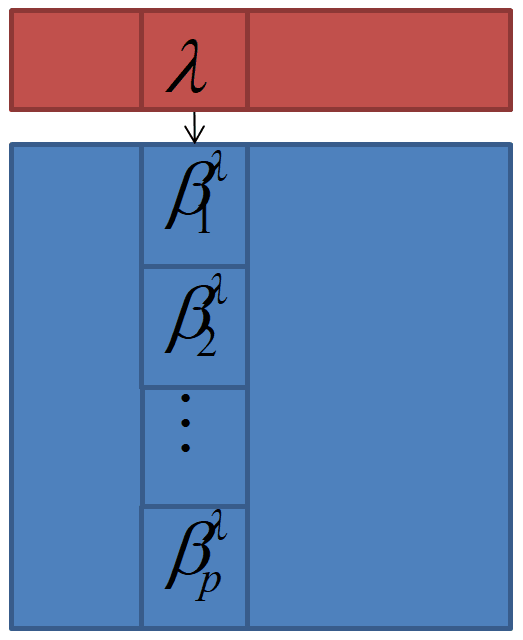

  - $code$

```r
 get_group_beta<-function(y,x,nlam=100,mu=1,std=TRUE)
{
  if (std) {                        #对数据做标准化
    y <- scale(y, scale=FALSE)
    x <- scale(x, scale=apply(x, 2, sd)*sqrt(nrow(x)-1))
    fac <- 1/attr(x, "scaled:scale")
  } else
    fac <- rep(1, ncol(x))
  lam<-get_lamda(y,x,nlam)        #调用get_lamda函数
  for(i in 1:nlam){
    res$sol[i]<-get_beta(y,x,fac,lam,mu=1,maxit=c(100,100),epis=c(1e-5,1e-5))
    res$lam[i]<-lam[i]
  }
  res
}
```

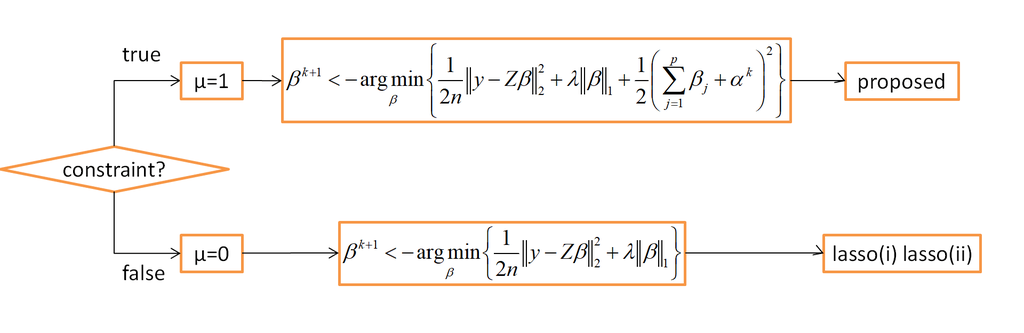

  - code

```r
select_GIC <- function(y, x, nlam=100, constr=TRUE) {
  if (constr)
    res <- get_group_beta(y,x,nlam=100,mu=1,std=TRUE)   #有约束对应mu=1
  else
    res <- get_group_beta(y,x,nlam=100,mu=0,std=TRUE)   #有约束对应mu=0
  n <- length(y)
  fit <- log(colMeans((y - matrix(res$int, n, length(res$lam), byrow=TRUE) - x %*% res$sol)^2))
  a <- switch("bic", bic=log(n), aic=2, ft=log(log(n))*log(max(ncol(x), n)))/n
  if (constr)
    gics <- fit + a*(colSums(res$sol != 0) - 1)
  else
    gics <- fit + a*colSums(res$sol != 0)
  ilam <- which.min(gics)                      #找到最优的lamda对应的下标
  list(bet=res$sol[, ilam], lam=res$lam[ilam])
}
```

## Three algorithms

- **Lasso (i) （有零和约束）**
  $$\hat{\beta}_{\backslash p}=\text{argmin}_{\beta_{\backslash p}}(\frac{1}{2n}||y-Z^p \beta_{\backslash p}||_2^2+\lambda||\beta_{\backslash p}||_1)$$
  $$\hat{\beta}_p=-1^T\beta_{\backslash p}$$

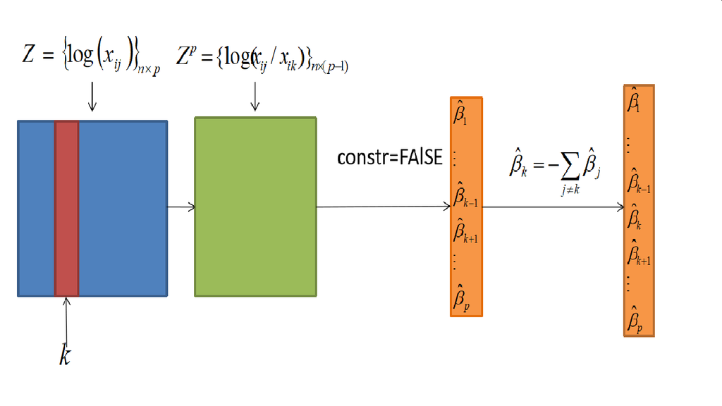

- **Lasso (ii) （无零和约束）**
  $$\hat{\beta}=\text{argmin}_{\beta}(\frac{1}{2n}||y-Z\beta||^{2}+\lambda||\beta||_{1})$$
- **Proposed （有零和约束）**
  $$\hat{\beta}=\text{argmin}_{\beta}(\frac{1}{2n}||y-Z\beta||^{2}+\lambda||\beta||_{1})$$
  $$\text{subject to} \,\,\sum_{j=1}^{p}\beta_j=0$$
- **code**

```r
methods <- function(n=50, p=30, fam="ln", rou=0.2) {
    load(paste("data/dat","n=", n, "p=", p, "rou=", rou, fam, ".rda", sep=" "))
    result <- vector("list",100)
    for (i in 1:100) {
  # Lasso (i)
        k <- sample(1:p, 1)
        new_z <- data[[i]]$z[, -k] - data[[i]]$z[, k]
        ans <- select_GIC(data[[i]]$y, new_z, constr=FALSE)
        result[[i]]$bet1 <- -sum(ans$bet)
        if (k > 1) result[[i]]$bet1 <- c(ans$bet[1:(k - 1)], result[[i]]$bet1)
        if (k < p) result[[i]]$bet1 <- c(result[[i]]$bet1, ans$bet[k:(p - 1)])

  # Lasso (ii)
        ans <- select_GIC(data[[i]]$y, data[[i]]$z, constr=FALSE)
        result[[i]]$bet2 <- ans$bet; result[[i]]$lam2 <- ans$lam

    # Proposed
        ans <- select_GIC(data[[i]]$y, data[[i]]$z)
        result[[i]]$bet <- ans$bet; result[[i]]$lam <- ans$lam
    }
    save(result, file=paste("data/res","n=", n, "p=", p, "rou=", rou, fam, ".rda", sep=" "))
    print(paste("data/res","n=", n, "p=", p, "rou=", rou, fam, ".rda", sep=" "))
}
```

## Simulations

- **generated the covariate data**
  - We generated the covariate data in the following way. We first generated an $n × p$ data matrix $W = (w_{i j})$ from a multivariate normal distribution $N_p(\theta,\Sigma)$, and then obtained the covariate matrix $X=(x_{i j})$ by the transformation $x_{i j}=exp(w_{i j})/\sum_{k=1}^pexp(w_{i k})$. The covariates generated thus follow a logistic normal distribution (Aitchison & Shen, 1980). To reflect the fact that the components of a composition in metagenomic data often differ by orders of magnitude, we let $θ = (θ_ j)$ with $θ_ j = \text{log}(0·5p)$ for $j = 1,\cdots,5$ and $θ_ j=0$ otherwise. To describe different levels of correlations among the components, we let $\Sigma=(\rho^{|i-j|})$ with $ρ = 0.2\,\, or \,\,0.5$. We generated the responses according to model (2) with $β^∗ = (1,-0.8,0.6,0,0,-1.5,-0.5,1.2,0,\cdots,0)^T$ and $\sigma= 0.5$, so that three of the six nonzero coefficients were among the five major components and the rest were among the minor components.
- **code**

```r
#基于模型二生成协变量数据
simulations <- function(n=50, p=30, rou=0.2) {
  theta <- log(c(rep(p/2, 5), rep(1, p - 5))) #theta=(theta j)
    beta <- c(1, -0.8, 0.6, 0, 0, -1.5, -0.5, 1.2, rep(0, p - 8)) #beta*
    sigma <- matrix(, p, p)
    sigma <- rou^abs(row(sigma) - col(sigma)) #sigma=(rou^(i-j)的绝对值)
    data <- vector("list",100)
    for (i in 1:100) { #重复100次模拟
        x <- switch("ln", ln={x <- exp(rmvnorm(n, theta, sigma)); x/rowSums(x)}, dir=rdirichlet(n, c(rep(p/2, 5), rep(1, p - 5))))#生成一个多维正态随机矩阵
        z <- log(x)
        y <- rnorm(n, z %*% beta, 0.5) #y是z*beta矩阵乘积做一个微小扰动
        data[[i]] <- list(y=y, z=z, beta=beta)
    }
    save(data, file=paste("data/dat","n=", n, "p=", p, "rou=", rou, fam, ".rda", sep=" "))
}
```

- **$\text{six}\,\,\,\, \text{performance}\,\,\, \text{measures}$**
  - **PE(prediction error)**
    $$\text{PE}=||y-Z\hat{\beta}||_2^2/n$$
  - **$L_q\,\,\,\,\text{loss}$**
    $$||\hat{\beta}-\beta^*||_q\,\,\,\,\,\,\,\,\,q=1,2,\infty$$
  - **FP (the number of false postives)**
  - **NP (the number of false negatives)**
- **code**

```r
output <- function(n, p, rou, fam="ln") {
  load(paste("data/new","n=", n, "p=", p, "rou=", rou, fam, ".rda", sep=" "))
  load(paste("data/res","n=", n, "p=", p, "rou=", rou, fam, ".rda", sep=" "))
  len <- length(result)

  pe1 <- numeric(len)
  l11 <- numeric(len)
  l21 <- numeric(len)
  linf1 <- numeric(len)
  fp1 <- numeric(len)
  fn1 <- numeric(len)

  pe2 <- numeric(len)
  l12 <- numeric(len)
  l22 <- numeric(len)
  linf2 <- numeric(len)
  fp2 <- numeric(len)
  fn2 <- numeric(len)

  pe <- numeric(len)
  l1 <- numeric(len)
  l2 <- numeric(len)
  linf <- numeric(len)
  fp <- numeric(len)
  fn <- numeric(len)

  for (i in 1:len) {
  # Lasso (i)
    del <- result[[i]]$bet1.gic - data[[i]]$bet #误差

    pe1[i] <- sum((data[[i]]$y - result[[i]]$int1.gic - data[[i]]$z %*% result[[i]]$bet1.gic)^2)/n #预测误差PE
    l11[i] <- sum(abs(del)) #L1误差 L1 loss
      l21[i] <- sum(del^2) #L2误差 L2 loss
      linf1[i] <- max(abs(del)) #L∞误差 L∞ loss
      fp1[i] <- sum(result[[i]]$bet1.gic != 0 & data[[i]]$bet == 0) #假阳性 FP
      fn1[i] <- sum(result[[i]]$bet1.gic == 0 & data[[i]]$bet != 0) #假阴性 FN

  # Lasso (ii)
      del <- result[[i]]$bet2.gic - data[[i]]$bet #误差

      pe2[i] <- sum((data[[i]]$y - result[[i]]$int2.gic - data[[i]]$z %*% result[[i]]$bet2.gic)^2)/n #预测误差PE
      l12[i] <- sum(abs(del)) #L1误差 L1 loss
      l22[i] <- sum(del^2) #L2误差 L2 loss
      linf2[i] <- max(abs(del)) #L∞误差 L∞ loss
      fp2[i] <- sum(result[[i]]$bet2.gic != 0 & data[[i]]$bet == 0) #假阳性 FP
      fn2[i] <- sum(result[[i]]$bet2.gic == 0 & data[[i]]$bet != 0) #假阴性 FN

  # Proposed
      del <- result[[i]]$bet.gic - data[[i]]$bet #误差

      pe[i] <- sum((data[[i]]$y - result[[i]]$int.gic - data[[i]]$z %*% result[[i]]$bet.gic)^2)/n #预测误差PE
      l1[i] <- sum(abs(del)) #L1误差 L1 loss
      l2[i] <- sum(del^2) #L2误差 L2 loss
      linf[i] <- max(abs(del)) #L∞误差 L∞ loss
      fp[i] <- sum(result[[i]]$bet.gic != 0 & data[[i]]$bet == 0) #假阳性 FP
      fn[i] <- sum(result[[i]]$bet.gic == 0 & data[[i]]$bet != 0) #假阴性 FN
  }
  first_group<-data.frame("PE"=c(paste(as.character(round(mean(pe1),2)),"(",round(sd(pe1)/sqrt(len),2),")"),paste(as.character(round(mean(pe2),2)),"(",round(sd(pe2)/sqrt(len),2),")"),paste(as.character(round(mean(pe),2)),"(",round(sd(pe)/sqrt(len),2),")")),"L1 loss"=c(paste(as.character(round(mean(l11),2)),"(",round(sd(l11)/sqrt(len),2),")"),paste(as.character(round(mean(l12),2)),"(",round(sd(l12)/sqrt(len),2),")"),paste(as.character(round(mean(l1),2)),"(",round(sd(l1)/sqrt(len),2),")")),"L2 loss"=c(paste(as.character(round(mean(l21),2)),"(",round(sd(l21)/sqrt(len),2),")"),paste(as.character(round(mean(l22),2)),"(",round(sd(l22)/sqrt(len),2),")"),paste(as.character(round(mean(l2),2)),"(",round(sd(l2)/sqrt(len),2),")")),"Linf loss"=c(paste(as.character(round(mean(linf1),2)),"(",round(sd(linf1)/sqrt(len),2),")"),paste(as.character(round(mean(linf2),2)),"(",round(sd(linf2)/sqrt(len),2),")"),paste(as.character(round(mean(linf),2)),"(",round(sd(linf)/sqrt(len),2),")")),"FP"=c(paste(as.character(round(mean(fp1),2)),"(",round(sd(fp1)/sqrt(len),2),")"),paste(as.character(round(mean(fp2),2)),"(",round(sd(fp2)/sqrt(len),2),")"),paste(as.character(round(mean(fp),2)),"(",round(sd(fp)/sqrt(len),2),")")),"FN"=c(paste(as.character(round(mean(fn1),2)),"(",round(sd(fn1)/sqrt(len),2),")"),paste(as.character(round(mean(fn2),2)),"(",round(sd(fn2)/sqrt(len),2),")"),paste(as.character(round(mean(fn),2)),"(",round(sd(fn)/sqrt(len),2),")")))
  rownames(first_group)<-c("Lasso (i)","Lasso (ii)","Proposed")
  library(kableExtra)
  kable(first_group) %>%
  kable_styling("striped", full_width = F)
}
```

**The first group**

```r
first_group<-data.frame("PE"=c(paste(0.43,"(",0.01,")"),paste(0.42,"(",0.01,")"),paste(0.42,"(",0.01,")")),"L1 loss"=c(paste(1.16,"(",0.03,")"),paste(1.10,"(",0.03,")"),paste(1.05,"(",0.03,")")),"L2 loss"=c(paste(0.19,"(",0.01,")"),paste(0.19,"(",0.01,")"),paste(0.18,"(",0.01,")")),"Linf loss"=c(paste(0.25,"(",0.01,")"),paste(0.25,"(",0.01,")"),paste(0.24,"(",0.01,")")),"FP"=c(paste(5.44,"(",0.29,")"),paste(4.15,"(",0.28,")"),paste(3.57,"(",0.23,")")),"FN"=c(paste(0,"(",0,")"),paste(0,"(",0,")"),paste(0,"(",0,")")))
rownames(first_group)<-c("Lasso (i)","Lasso (ii)","Proposed")
```

```r
library(kableExtra)
kable(first_group) %>%
kable_styling("striped", full_width = F)
```

|  | PE | L1.loss | L2.loss | Linf.loss | FP | FN |
| --- | --- | --- | --- | --- | --- | --- |
| Lasso (i) | 0.43 ( 0.01 ) | 1.16 ( 0.03 ) | 0.19 ( 0.01 ) | 0.25 ( 0.01 ) | 5.44 ( 0.29 ) | 0 ( 0 ) |
| Lasso (ii) | 0.42 ( 0.01 ) | 1.1 ( 0.03 ) | 0.19 ( 0.01 ) | 0.25 ( 0.01 ) | 4.15 ( 0.28 ) | 0 ( 0 ) |
| Proposed | 0.42 ( 0.01 ) | 1.05 ( 0.03 ) | 0.18 ( 0.01 ) | 0.24 ( 0.01 ) | 3.57 ( 0.23 ) | 0 ( 0 ) |

$$\text{n}=50\,\,\,\,\,\,\text{p}=30\,\,\,\,\rho=0.2\,\,\,\,(results\,\,\,\ in\,\,\, the\,\,\, article)$$

```r
  output(n=50, p=30, rou=0.2, fam="ln")
```

|  | PE | L1.loss | L2.loss | Linf.loss | FP | FN |
| --- | --- | --- | --- | --- | --- | --- |
| Lasso (i) | 0.43 ( 0.02 ) | 1.09 ( 0.04 ) | 0.17 ( 0.01 ) | 0.23 ( 0.01 ) | 5.3 ( 0.31 ) | 0.01 ( 0.01 ) |
| Lasso (ii) | 0.44 ( 0.02 ) | 1.07 ( 0.03 ) | 0.18 ( 0.01 ) | 0.25 ( 0.01 ) | 4.07 ( 0.29 ) | 0 ( 0 ) |
| Proposed | 0.42 ( 0.01 ) | 0.99 ( 0.03 ) | 0.15 ( 0.01 ) | 0.22 ( 0.01 ) | 4.32 ( 0.28 ) | 0.01 ( 0.01 ) |

$$\text{n}=50\,\,\,\,\,\,\text{p}=30\,\,\,\,\rho=0.2\,\,\,(our\,\,\,\, results)$$

**The second group**

```r
  second_group<-data.frame("PE"=c(paste(0.45,"(",0.01,")"),paste(0.42,"(",0.01,")"),paste(0.41,"(",0.01,")")),"L1 loss"=c(paste(1.25,"(",0.03,")"),paste(1.12,"(",0.02,")"),paste(1.07,"(",0.02,")")),"L2 loss"=c(paste(0.24,"(",0.01,")"),paste(0.21,"(",0.01,")"),paste(0.19,"(",0.01,")")),"Linf loss"=c(paste(0.27,"(",0.01,")"),paste(0.26,"(",0.01,")"),paste(0.24,"(",0.01,")")),"FP"=c(paste(4.94,"(",0.28,")"),paste(2.96,"(",0.23,")"),paste(3.03,"(",0.24,")")),"FN"=c(paste(0,"(",0,")"),paste(0,"(",0,")"),paste(0,"(",0,")")))
  rownames(second_group)<-c("Lasso (i)","Lasso (ii)","Proposed")
```

```r
library(kableExtra)
kable(second_group) %>%
kable_styling("striped", full_width = F)
```

|  | PE | L1.loss | L2.loss | Linf.loss | FP | FN |
| --- | --- | --- | --- | --- | --- | --- |
| Lasso (i) | 0.45 ( 0.01 ) | 1.25 ( 0.03 ) | 0.24 ( 0.01 ) | 0.27 ( 0.01 ) | 4.94 ( 0.28 ) | 0 ( 0 ) |
| Lasso (ii) | 0.42 ( 0.01 ) | 1.12 ( 0.02 ) | 0.21 ( 0.01 ) | 0.26 ( 0.01 ) | 2.96 ( 0.23 ) | 0 ( 0 ) |
| Proposed | 0.41 ( 0.01 ) | 1.07 ( 0.02 ) | 0.19 ( 0.01 ) | 0.24 ( 0.01 ) | 3.03 ( 0.24 ) | 0 ( 0 ) |

$$\text{n}=100\,\,\,\,\,\,\text{p}=200\,\,\,\,\rho=0.2\,\,\,\,(results\,\,\,\ in\,\,\, the\,\,\, article)$$

```r
  output(n=100, p=200, rou=0.2, fam="ln")
```

|  | PE | L1.loss | L2.loss | Linf.loss | FP | FN |
| --- | --- | --- | --- | --- | --- | --- |
| Lasso (i) | 0.47 ( 0.01 ) | 1.3 ( 0.03 ) | 0.26 ( 0.01 ) | 0.28 ( 0.01 ) | 5.1 ( 0.25 ) | 0 ( 0 ) |
| Lasso (ii) | 0.45 ( 0.01 ) | 1.18 ( 0.03 ) | 0.24 ( 0.01 ) | 0.27 ( 0.01 ) | 2.68 ( 0.24 ) | 0 ( 0 ) |
| Proposed | 0.44 ( 0.01 ) | 1.14 ( 0.03 ) | 0.22 ( 0.01 ) | 0.25 ( 0.01 ) | 2.62 ( 0.21 ) | 0 ( 0 ) |

$$\text{n}=100\,\,\,\,\,\,\text{p}=200\,\,\,\,\rho=0.2\,\,\,(our\,\,\,\, results)$$
**The third group**

```r
  third_group<-data.frame("PE"=c(paste(0.82,"(",0.05,")"),paste(0.66,"(",0.03,")"),paste(0.61,"(",0.02,")")),"L1 loss"=c(paste(2.01,"(",0.07,")"),paste(1.68,"(",0.05,")"),paste(1.57,"(",0.04,")")),"L2 loss"=c(paste(0.69,"(",0.06,")"),paste(0.52,"(",0.03,")"),paste(0.43,"(",0.03,")")),"Linf loss"=c(paste(0.42,"(",0.02,")"),paste(0.38,"(",0.01,")"),paste(0.34,"(",0.01,")")),"FP"=c(paste(5.18,"(",0.27,")"),paste(2.84,"(",0.21,")"),paste(3.10,"(",0.22,")")),"FN"=c(paste(0.28,"(",0.08,")"),paste(0.13,"(",0.04,")"),paste(0.04,"(",0.02,")")))
  rownames(third_group)<-c("Lasso (i)","Lasso (ii)","Proposed")
```

```r
library(kableExtra)
kable(third_group) %>%
kable_styling("striped", full_width = F)
```

|  | PE | L1.loss | L2.loss | Linf.loss | FP | FN |
| --- | --- | --- | --- | --- | --- | --- |
| Lasso (i) | 0.82 ( 0.05 ) | 2.01 ( 0.07 ) | 0.69 ( 0.06 ) | 0.42 ( 0.02 ) | 5.18 ( 0.27 ) | 0.28 ( 0.08 ) |
| Lasso (ii) | 0.66 ( 0.03 ) | 1.68 ( 0.05 ) | 0.52 ( 0.03 ) | 0.38 ( 0.01 ) | 2.84 ( 0.21 ) | 0.13 ( 0.04 ) |
| Proposed | 0.61 ( 0.02 ) | 1.57 ( 0.04 ) | 0.43 ( 0.03 ) | 0.34 ( 0.01 ) | 3.1 ( 0.22 ) | 0.04 ( 0.02 ) |

$$\text{n}=100\,\,\,\,\,\,\text{p}=1000\,\,\,\,\rho=0.2\,\,\,\,(results\,\,\,\ in\,\,\, the\,\,\, article)$$

```r
  output(n=100, p=1000, rou=0.2, fam="ln")
```

|  | PE | L1.loss | L2.loss | Linf.loss | FP | FN |
| --- | --- | --- | --- | --- | --- | --- |
| Lasso (i) | 0.84 ( 0.05 ) | 2.03 ( 0.07 ) | 0.7 ( 0.06 ) | 0.43 ( 0.02 ) | 5.08 ( 0.28 ) | 0.3 ( 0.08 ) |
| Lasso (ii) | 0.68 ( 0.04 ) | 1.7 ( 0.05 ) | 0.53 ( 0.04 ) | 0.39 ( 0.01 ) | 2.97 ( 0.23 ) | 0.12 ( 0.05 ) |
| Proposed | 0.62 ( 0.03 ) | 1.58 ( 0.04 ) | 0.43 ( 0.03 ) | 0.35 ( 0.01 ) | 3.22 ( 0.23 ) | 0.04 ( 0.03 ) |

$$\text{n}=100\,\,\,\,\,\,\text{p}=1000\,\,\,\,\rho=0.2\,\,\,(our\,\,\,\, results)$$
**The fourth group**

```r
  fourth_group<-data.frame("PE"=c(paste(0.46,"(",0.01,")"),paste(0.43,"(",0.01,")"),paste(0.42,"(",0.01,")")),"L1 loss"=c(paste(1.55,"(",0.05,")"),paste(1.40,"(",0.04,")"),paste(1.32,"(",0.04,")")),"L2 loss"=c(paste(0.35,"(",0.03,")"),paste(0.30,"(",0.02,")"),paste(0.28,"(",0.02,")")),"Linf loss"=c(paste(0.33,"(",0.01,")"),paste(0.31,"(",0.01,")"),paste(0.30,"(",0.01,")")),"FP"=c(paste(6.70,"(",0.32,")"),paste(5.00,"(",0.30,")"),paste(4.81,"(",0.27,")")),"FN"=c(paste(0.08,"(",0.04,")"),paste(0.02,"(",0.01,")"),paste(0.02,"(",0.01,")")))
  rownames(fourth_group)<-c("Lasso (i)","Lasso (ii)","Proposed")
```

```r
library(kableExtra)
kable(fourth_group) %>%
kable_styling("striped", full_width = F)
```

|  | PE | L1.loss | L2.loss | Linf.loss | FP | FN |
| --- | --- | --- | --- | --- | --- | --- |
| Lasso (i) | 0.46 ( 0.01 ) | 1.55 ( 0.05 ) | 0.35 ( 0.03 ) | 0.33 ( 0.01 ) | 6.7 ( 0.32 ) | 0.08 ( 0.04 ) |
| Lasso (ii) | 0.43 ( 0.01 ) | 1.4 ( 0.04 ) | 0.3 ( 0.02 ) | 0.31 ( 0.01 ) | 5 ( 0.3 ) | 0.02 ( 0.01 ) |
| Proposed | 0.42 ( 0.01 ) | 1.32 ( 0.04 ) | 0.28 ( 0.02 ) | 0.3 ( 0.01 ) | 4.81 ( 0.27 ) | 0.02 ( 0.01 ) |

$$\text{n}=50\,\,\,\,\,\,\text{p}=30\,\,\,\,\rho=0.5\,\,\,\,(results\,\,\,\ in\,\,\, the\,\,\, article)$$

```r
  output(n=50, p=30, rou=0.5, fam="ln")
```

|  | PE | L1.loss | L2.loss | Linf.loss | FP | FN |
| --- | --- | --- | --- | --- | --- | --- |
| Lasso (i) | 0.45 ( 0.02 ) | 1.46 ( 0.04 ) | 0.3 ( 0.02 ) | 0.31 ( 0.01 ) | 6.51 ( 0.34 ) | 0.04 ( 0.02 ) |
| Lasso (ii) | 0.45 ( 0.02 ) | 1.35 ( 0.04 ) | 0.3 ( 0.02 ) | 0.32 ( 0.01 ) | 4.77 ( 0.26 ) | 0.07 ( 0.03 ) |
| Proposed | 0.43 ( 0.01 ) | 1.27 ( 0.04 ) | 0.26 ( 0.02 ) | 0.29 ( 0.01 ) | 5.01 ( 0.3 ) | 0.05 ( 0.02 ) |

$$\text{n}=50\,\,\,\,\,\,\text{p}=30\,\,\,\,\rho=0.5\,\,\,(our\,\,\,\, results)$$
**The fifth group**

```r
  fifth_group<-data.frame("PE"=c(paste(0.62,"(",0.03,")"),paste(0.47,"(",0.01,")"),paste(0.45,"(",0.01,")")),"L1 loss"=c(paste(2.11,"(",0.07,")"),paste(1.60,"(",0.04,")"),paste(1.54,"(",0.03,")")),"L2 loss"=c(paste(0.75,"(",0.06,")"),paste(0.45,"(",0.03,")"),paste(0.40,"(",0.02,")")),"Linf loss"=c(paste(0.48,"(",0.02,")"),paste(0.37,"(",0.01,")"),paste(0.36,"(",0.01,")")),"FP"=c(paste(7.16,"(",0.39,")"),paste(4.61,"(",0.27,")"),paste(4.60,"(",0.29,")")),"FN"=c(paste(0.33,"(",0.08,")"),paste(0.09,"(",0.05,")"),paste(0.01,"(",0.01,")")))
  rownames(fifth_group)<-c("Lasso (i)","Lasso (ii)","Proposed")
```

```r
library(kableExtra)
kable(fifth_group) %>%
kable_styling("striped", full_width = F)
```

|  | PE | L1.loss | L2.loss | Linf.loss | FP | FN |
| --- | --- | --- | --- | --- | --- | --- |
| Lasso (i) | 0.62 ( 0.03 ) | 2.11 ( 0.07 ) | 0.75 ( 0.06 ) | 0.48 ( 0.02 ) | 7.16 ( 0.39 ) | 0.33 ( 0.08 ) |
| Lasso (ii) | 0.47 ( 0.01 ) | 1.6 ( 0.04 ) | 0.45 ( 0.03 ) | 0.37 ( 0.01 ) | 4.61 ( 0.27 ) | 0.09 ( 0.05 ) |
| Proposed | 0.45 ( 0.01 ) | 1.54 ( 0.03 ) | 0.4 ( 0.02 ) | 0.36 ( 0.01 ) | 4.6 ( 0.29 ) | 0.01 ( 0.01 ) |

$$\text{n}=100\,\,\,\,\,\,\text{p}=200\,\,\,\,\rho=0.5\,\,\,\,(results\,\,\,\ in\,\,\, the\,\,\, article)$$

```r
  output(n=100, p=200, rou=0.5, fam="ln")
```

|  | PE | L1.loss | L2.loss | Linf.loss | FP | FN |
| --- | --- | --- | --- | --- | --- | --- |
| Lasso (i) | 0.68 ( 0.04 ) | 2.22 ( 0.07 ) | 0.83 ( 0.06 ) | 0.5 ( 0.02 ) | 6.99 ( 0.36 ) | 0.51 ( 0.1 ) |
| Lasso (ii) | 0.49 ( 0.02 ) | 1.66 ( 0.04 ) | 0.48 ( 0.03 ) | 0.38 ( 0.01 ) | 4.36 ( 0.27 ) | 0.06 ( 0.03 ) |
| Proposed | 0.48 ( 0.01 ) | 1.59 ( 0.04 ) | 0.43 ( 0.02 ) | 0.36 ( 0.01 ) | 4.82 ( 0.31 ) | 0.04 ( 0.02 ) |

$$\text{n}=100\,\,\,\,\,\,\text{p}=200\,\,\,\,\rho=0.5\,\,\,(our\,\,\,\, results)$$
**The sixth group**

```r
  sixth_group<-data.frame("PE"=c(paste(1.51,"(",0.08,")"),paste(0.94,"(",0.05,")"),paste(0.91,"(",0.07,")")),"L1 loss"=c(paste(3.70,"(",0.08,")"),paste(2.72,"(",0.08,")"),paste(2.59,"(",0.08,")")),"L2 loss"=c(paste(2.32,"(",0.11,")"),paste(1.40,"(",0.08,")"),paste(1.25,"(",0.09,")")),"Linf loss"=c(paste(0.81,"(",0.02,")"),paste(0.62,"(",0.02,")"),paste(0.59,"(",0.02,")")),"FP"=c(paste(3.39,"(",0.23,")"),paste(2.44,"(",0.20,")"),paste(3.73,"(",0.29,")")),"FN"=c(paste(2.55,"(",0.12,")"),paste(1.29,"(",0.13,")"),paste(0.99,"(",0.13,")")))
  rownames(sixth_group)<-c("Lasso (i)","Lasso (ii)","Proposed")
```

```r
kable(sixth_group) %>%
kable_styling("striped", full_width = F)
```

|  | PE | L1.loss | L2.loss | Linf.loss | FP | FN |
| --- | --- | --- | --- | --- | --- | --- |
| Lasso (i) | 1.51 ( 0.08 ) | 3.7 ( 0.08 ) | 2.32 ( 0.11 ) | 0.81 ( 0.02 ) | 3.39 ( 0.23 ) | 2.55 ( 0.12 ) |
| Lasso (ii) | 0.94 ( 0.05 ) | 2.72 ( 0.08 ) | 1.4 ( 0.08 ) | 0.62 ( 0.02 ) | 2.44 ( 0.2 ) | 1.29 ( 0.13 ) |
| Proposed | 0.91 ( 0.07 ) | 2.59 ( 0.08 ) | 1.25 ( 0.09 ) | 0.59 ( 0.02 ) | 3.73 ( 0.29 ) | 0.99 ( 0.13 ) |

$$\text{n}=100\,\,\,\,\,\,\text{p}=1000\,\,\,\,\rho=0.5\,\,\,\,(results\,\,\,\ in\,\,\, the\,\,\, article)$$

```r
  output(n=100, p=1000, rou=0.5, fam="ln")
```

|  | PE | L1.loss | L2.loss | Linf.loss | FP | FN |
| --- | --- | --- | --- | --- | --- | --- |
| Lasso (i) | 1.47 ( 0.05 ) | 3.72 ( 0.06 ) | 2.28 ( 0.06 ) | 0.81 ( 0.01 ) | 3.48 ( 0.22 ) | 2.55 ( 0.09 ) |
| Lasso (ii) | 0.97 ( 0.04 ) | 2.77 ( 0.07 ) | 1.45 ( 0.08 ) | 0.63 ( 0.02 ) | 2.16 ( 0.22 ) | 1.26 ( 0.12 ) |
| Proposed | 0.84 ( 0.04 ) | 2.54 ( 0.07 ) | 1.15 ( 0.07 ) | 0.57 ( 0.02 ) | 3.91 ( 0.29 ) | 0.87 ( 0.11 ) |

$$\text{n}=100\,\,\,\,\,\,\text{p}=1000\,\,\,\,\rho=0.5\,\,\,(our\,\,\,\, results)$$

## References

- Rizzo, M. L. Statistical computing with R
- Trevor Hastie, Robert Tishirani, Jerome Friedman The Elements of Statistical learning
- Peter Buhlmann Sara van de geer, Statistics for High-Dimensional Data